# geneticae

Statistical Tools for the Analysis of Multi Environment Agronomic Trials

Julia Angelini Marcos Prunello Gerardo Cervigni Centro de Estudios Fotosintéticos y Bioquímicos Universidad Nacional de Rosario

2021-09-09

## Getting started

You can install the development version from [GitHub](https://github.com/):

```r
# install.packages("devtools")
devtools::install_github("jangelini/geneticae")
```

**Loading the package.** Once the `geneticae` package is installed, it needs to be loaded by `library(geneticae)`.

**Help files.** Detailed information on `geneticae` package functions can be obtained from help files using `help(package="geneticae")`. The help file for a function, for example `imputation`, in a R session can be obtained using `?imputation` or `help(imputation)`.

## Introduction

Understanding the relationship between crops performance and environment is a key problem for plant breeders and geneticists. In advanced stages of breeding programs, where few genotypes are evaluated, multi-environmental trials (MET) is one of the most common experiments. They are conducted by testing a number of genotypes across multiple environments, allowing the identification of superior genotypes. Crop performance is a function of genotype (G), environment (E) and genotype x environment interaction (GEI). METs are essential due to the presence of GEI which generates differential genotypic responses in the different environments evaluated (Crossa et al., 1990; Cruz Medina, 1992; Kang and Magari, 1996). This is a particular problem for plant breeders (Giauffret et al., 2000), therefore appropriate statistical methods should be used to obtain an adequate GEI analysis.

A proper analysis of MET data is essential for the success of a breeding program. The average performance of genotypes in environments only can be considered in absence of IGA (Yan and Kang, 2003). However, IGA is inevitable and genotypes means comparison is not enough, therefore a more appropriate statistical methodology must be used. The most widely used to analyze MET data are based on regression models, analysis of variance (ANOVA) and multivariate analysis techniques. Two multiplicative models have increased their popularity among plant breeders as graphic analysis tools for the study of IGA and the analyzes derived from it: Additive Main effects and Multiplicative Interaction model (AMMI) (Kempton, 1984; Gauch, 1988) and site regression model (SREG) (Cornelius et al., 1996; Gauch and Zobel, 1997). However, these models are not always efficient enough to analyze MET data structure of plant breeding programs. It has serious limitations in presence of atypical observations, as well as in front of missing information. Both phenomena are more a rule rather than an exception when considering real data. To reduce this handicap, several imputation alternatives and also an AMMI robust model were proposed recently in literature.

There are numerous packages to analyze MET data but they must be correctly identified and combined. `geneticae` package is created to gathers the most useful functions and also offers new ones recently available in literature. In addition, `geneticae` package is less restrictive regarding the input dataset format so so there is no need to preprocess the data to apply the functions. Genotypes, environments, repetitions (if any) and phenotypic trait of interest can be present in any order and there is no restriction on columns names. Also, extra information that will not be used in the analysis may be present in the dataset. Finally, the biplots created can be customized by the user.

## datasets in `geneticae`

The `geneticae` package provides two datasets to illustrate the methodology included to analize MET data.

- `yan.winterwheat` dataset: yield of 18 winter wheat varieties grown in nine environments in Ontario at 1993. Although four blocks or replicas in each environment were performed in the experiment, only yield mean for each variety and environment combination was available in the dataset obtained from agridat package (Wright, 2018).

```r
library(geneticae)
data(yan.winterwheat)
head(yan.winterwheat)
```

```
##   gen  env yield
## 1 Ann BH93 4.460
## 2 Ari BH93 4.417
## 3 Aug BH93 4.669
## 4 Cas BH93 4.732
## 5 Del BH93 4.390
## 6 Dia BH93 5.178
```

- `plrv` dataset: resistance study to PLRV (Patato Leaf Roll Virus) causing leaf curl. 28 genotypes were experimented at 6 locations in Peru. Each clone was evaluated three times in each environment, and yield, plant weight and plot were registered. This dataset was obtained from agricolae package (de Mendiburu, 2020).

```r
data(plrv)
head(plrv)
```

```
##   Genotype Locality Rep WeightPlant WeightPlot    Yield
## 1   102.18     Ayac   1   0.5100000       5.10 18.88889
## 2   104.22     Ayac   1   0.3450000       2.76 12.77778
## 3   121.31     Ayac   1   0.5425000       4.34 20.09259
## 4   141.28     Ayac   1   0.9888889       8.90 36.62551
## 5   157.26     Ayac   1   0.6250000       5.00 23.14815
## 6    163.9     Ayac   1   0.5120000       2.56 18.96296
```

## Running `geneticae`

### AMMI model

The classic GE biplot for `yan.winterwheat` dataset is shown in Figure 1.

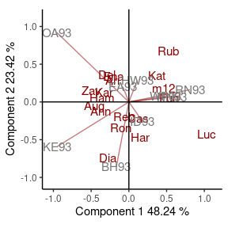

Figure 1: classic GE biplot

```r
rAMMI(yan.winterwheat,genotype="gen",environment="env", response="yield", type = "AMMI", footnote = F, titles = F)
```

The AMMI model, in its standard form, implicitly assumes equal weights for all entries of two-way dataset and that no outliers are present in the data. To overcome the problem of data contamination with outlying observations, Rodrigues et al. (2015) propose five robust AMMI models, which can be obtained in two stages as follows: (i) use the robust regression based on the M-Huber estimator (Huber, 1981) to replace the ANOVA model; and (ii) use a robust SVD/PCA procedure to replace the standard SVD. Robust AMMI models there are no available in an R package. All robusts biplots proposed by Rodrigues et al. (2015) can be obtained using `rAMMI()` function, indicating in `type` which one you want to obtain: `"rAMMI"`, `"hAMMI"`, `"gAMMI"`, `"lAMMI"` or `"ppAMMI"`. However, as `yan.winterwheat` dataset does not present outliers, the conclusions obtained with robust biplots will not differ from those made with the classic biplot (Rodrigues, et al. 2015). Thus, there is no point in interpreting robust biplots in this example.

### Site regression model

Site regression model also named genotype plus genotype-by-environment (GGE) model is another powerful tool for effective analysis and interpretation of MET data structure in breeding programs. GGE explore genotype (G) and IGA effect performing a SVD on the residuals matrix obtained from a one-way ANOVA with fixed effects for environments. To select cultivars the effect of G and IGA must be considered simultaneously so SREG model is superior to AMMI for visualizing patterns in MET data.

`GGEmodel()` function it is a modification of `GGEModel()` function of GGEBiplots package (Dumble, 2017). As `rAMMI()` data in long format is required, repetitions and extra variables that will not be used in the analysis may be present in the dataset are allowed, and all combination of genotypes and environments must be evaluated.

```r
GGE1 <- GGEmodel(yan.winterwheat, genotype="gen",environment="env", response="yield", centering = "tester")
```

The output from `GGEmodel()` function is a list with the following elements:

- `coordgenotype`: plotting coordinates for genotypes from all components.
- `coordenviroment`: plotting coordinates for environments from all components.
- `eigenvalues`: vector of eigenvalues from each component.
- `vartotal`: overall variance.
- `varexpl`: percentage of variance explained by each component.
- `labelgen`: genotype names.
- `labelenv`: environment names.
- `axes`: axis labels.
- `Data`: scaled and centered input data.
- `centering`: centering method.
- `scaling`: scaling method.
- `SVP`: SVP method.

The result of the first two multiplicative terms of the SVD is often presented in a biplot called genotype plus genotype x environment interaction (GGE) (Yan et al., 2000). Such biplot represents a rank-two approximation of the G + IGA effects. Increasingly, plant breeders have found GGE biplots as useful tools in mega environment analysis (Yan et al., 2001; Yan and Rajcan, 2002), and genotype and environment evaluation (Bhan et al., 2005; Kang et al., 2006; Yan et al., 2007). The GGE biplot visually addresses many issues relative to genotype and test environment evaluation. Considering average genotypes performance, GGE biplot allows to evaluate specific and general adaptation. In addition, environments could be visually evaluated and grouped according to their ability to discriminate among genotypes and their representativeness of other test environments. GGE biplot reveals the which-won-where pattern and allows to recommend specific genotypes for each ME (Yan and Tinker, 2005).

Basic biplot, in which the 78% of the total variability of G + GE is explained, it si obtained indicating `type="Biplot"` (Figure 2).

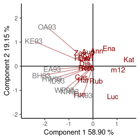

Figure 2: basic biplot

```r
GGEPlot(GGE1, type="Biplot", footnote = F, titles = F)
```

Breeders in general wanted to identify the most suitable cultivars for their area. To do this with GGE biplot, Yan and Hunt (2002) suggest making an axis of the environment of interest, for example OA93, drawing a line that passes through environment marker and biplot origin. Such graph is obtained by indicating `type="Selected Environment"` and the environment to examine `selectedE = "OA93"` (Figure 3).

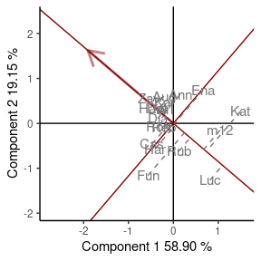

Figure 3: comparison of cultivare performance in a selected environment (OA93)

```r
GGEPlot(GGE1, type="Selected Environment", selectedE = "OA93", footnote = F, titles = F)
```

Another interest of plant breeders is to determine which is the most suitable environment for a cultivar. Yan and Hunt (2002) suggest plotting a line that passes through biplot origin and *Luc* marker, which we will call *Luc* axis. Figure 4 illustrates how to visualize the relative adaptation of cultivar *Luc* in different environments, `type="Selected Genotype"` and the genotype to examine `selectedG = "Luc"` are the arguments required.

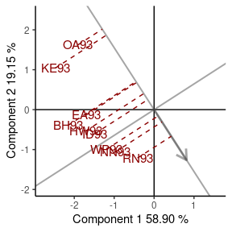

Figure 4: comparison of the performance of cultivar Luc in different environments

```r
GGEPlot(GGE1, type="Selected Genotype", selectedG = "Luc", footnote = F, titles = F)
```

To compare two cultivars, for example *Kat* and *Cas*, a connector line that link genotypes markers to be compared and also a perpendicular to the connector line is drawn (Figure 5).

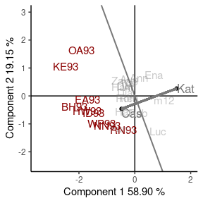

Figure 5: comparison of two cultivars, Kat and Cas

```r
GGEPlot(GGE1, type="Comparison of Genotype", selectedG1 = "Kat", selectedG2 = "Cas", footnote = F, titles = F, axis_expand = 1.5)
```

The polygonal view of GGE biplot proposed by Yan (1999) provides an effective way to visualize the which-won-where pattern of an MET dataset (Figure 6). Vertex cultivars are those with the longest vectors, in their respective directions, which is a measure of the ability to respond to environments. The perpendicular lines on polygon sides divide the biplot into megaenvironments, each of which has a vertex cultivar, the one with the highest yield in all environments found in it.

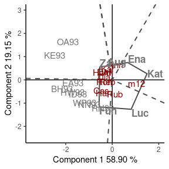

Figure 6: polygon view of the GGE biplot, showing which cultivar yielded best in which environments

```r
GGEPlot(GGE1, type="Which Won Where/What", footnote = F, titles = F, axis_expand = 1.5)
```

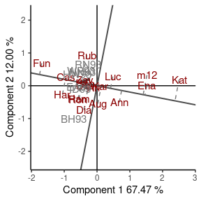

Figure 7: average environement view of the GGE biplot based on genotype-focused scaling, showing mean yield and stability of genotypes

```r
data<-yan.winterwheat
data<-data[data$env %in% c("BH93", "EA93","HW93", "ID93","NN93","RN93", "WP93"),]
GGE2 <- GGEmodel(data, genotype="gen", environment="env", response="yield", SVP="row")
GGEPlot(GGE2, type="Mean vs. Stability", footnote = F, titles = F)
```

GGE biplot allows to visualize mean yield and stability of genotypes in yield units **per se** (Figure 8). The ideal cultivar is represented by a small circle in Figure 8 as it has the highest yield and is absolutely stable. This ideal genotype is used as a reference for cultivar evaluation, as it rarely exists. The distance between cultivars and the ideal one can be used as a measure of convenience. Concentric circles help to visualize these distances. *Fun* is the closest to ideal, and therefore the most desirable followed by *cas* and *hay*, which in turn are followed by *rum*, *ham*, *rub*, *zav*, *del* and *reb*, etc.

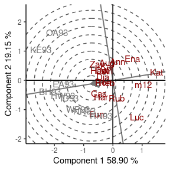

Figure 8: Classification of genotypes with respect to the ideal genotype

```r
GGEPlot(GGE1, type="Ranking Genotypes", footnote = F, titles = F)
```

Although METs are performed to evaluate cultivars, they are equally useful in environments evaluation. This includes several aspects: (i) evaluating whether the target region belongs to one or more megaenvironments; (ii) identify better test environments; (iii) detect redundant environments that do not provide additional information on cultivars; (iv) determine environments that can be used for indirect selection.

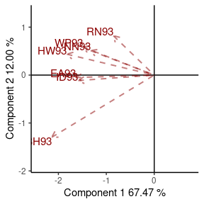

Figure 9: Relationship between environments

```r
GGE3 <- GGEmodel(data, genotype="gen", environment="env", response="yield", SVP="column")
GGEPlot(GGE3, type="Relationship Among Environments", footnote = F, titles = F)
```

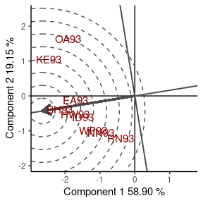

Figure 10: Classification of environments with respect to the ideal environment

```r
GGEPlot(GGE1, type="Ranking Environments", footnote = F, titles = F)
```

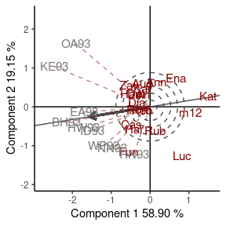

```r
GGEPlot(GGE1, type="Discrimination vs. representativeness", footnote = F, titles = F)
```

### Imputation methods

One major limitation of AMMI and SREG is that require a complete two-way data table. Although METs are designed so that all genotypes are evaluated in all environments, missing values are very common due to measurement errors or destruction of plants by animals, floods or harvest problems, in addition to the evaluations dynamics in which genotypes are incorporated and discarded because of their poor performance.

Numerous methodologies have been proposed in order to overcome the lack of balance problem. `imputation()` function includes severals methodsto overcome the problem of missing data, some of which recently pubish and not available in R package.

Since the `yan.winterwheat` dataset was complete, some observations are deleted in order to show how to obtained an imputed dataset with `"EM-AMMI"` method. To perform the remaining methods available: `"EM-SVD"`, `"Gabriel"`, `"WGabriel"` and `"EM-PCA"`, it must be indicated in the type argument of `imputation()` function.

```r
# Generating missing data
yan.winterwheat[1,3] <- NA
yan.winterwheat[3,3] <- NA
yan.winterwheat[2,3] <- NA
```

```r
imputation(yan.winterwheat, nPC = 2, genotype = "gen", environment = "env",
           response = "yield", type = "EM-AMMI")
```

```
##         BH93  EA93  HW93  ID93  KE93  NN93  OA93  RN93  WP93
## Ann 4.150120 4.150 2.849 3.084 5.940 4.450 4.351 4.039 2.672
## Ari 4.035814 4.771 2.912 3.506 5.699 5.152 4.956 4.386 2.938
## Aug 4.305244 4.578 3.098 3.460 6.070 5.025 4.730 3.900 2.621
## Cas 4.732000 4.745 3.375 3.904 6.224 5.340 4.226 4.893 3.451
## Del 4.390000 4.603 3.511 3.848 5.773 5.421 5.147 4.098 2.832
## Dia 5.178000 4.475 2.990 3.774 6.583 5.045 3.985 4.271 2.776
## Ena 3.375000 4.175 2.741 3.157 5.342 4.267 4.162 4.063 2.032
## Fun 4.852000 4.664 4.425 3.952 5.536 5.832 4.168 5.060 3.574
## Ham 5.038000 4.741 3.508 3.437 5.960 4.859 4.977 4.514 2.859
## Har 5.195000 4.662 3.596 3.759 5.937 5.345 3.895 4.450 3.300
## Kar 4.293000 4.530 2.760 3.422 6.142 5.250 4.856 4.137 3.149
## Kat 3.151000 3.040 2.388 2.350 4.229 4.257 3.384 4.071 2.103
## Luc 4.104000 3.878 2.302 3.718 4.555 5.149 2.596 4.956 2.886
## Reb 4.375000 4.701 3.655 3.592 6.189 5.141 3.933 4.208 2.925
## Ron 4.940000 4.698 2.950 3.898 6.063 5.326 4.302 4.299 3.031
## Rub 3.786000 4.969 3.379 3.353 4.774 5.304 4.322 4.858 3.382
## Zav 4.238000 4.654 3.607 3.914 6.641 4.830 5.014 4.363 3.111
## m12 3.340000 3.854 2.419 2.783 4.629 5.090 3.281 3.918 2.561
```

## References

Giauffret, C., Lothrop, J., Dorvillez, D., Gouesnard, B., Derieux, M., 2000. Genotype x environment interactions in maize hybrids from temperate or highland tropical origin. Crop Sci. 40, 1004-1012.

Sam Dumble (2017). GGEBiplots: GGE Biplots with ‘ggplot2’. R package version 0.1.1. https://CRAN.R-project.org/package=GGEBiplots

Felipe de Mendiburu (2020). agricolae: Statistical Procedures for Agricultural Research. R package version 1.3-2. https://CRAN.R-project.org/package=agricolae